# ETH_DCA

Introduction

Import packages

```python
import pandas as pd  #for data analysis and manipulation
import numpy as np #for numerical computing
import matplotlib.pyplot as plt #for data visualization
import seaborn as sns #for data visualization
import requests #HTTP request to call data from API
import json #to Work with json data
from ipywidgets import interact
```

Data

```python
df = pd.read_csv('Historical crypto data/coin_Ethereum.csv', low_memory=False)
```

Data preproccessing

```python
df.head(10)
```

|  | SNo | Name | Symbol | Date | High | Low | Open | Close | Volume | Marketcap |
| --- | --- | --- | --- | --- | --- | --- | --- | --- | --- | --- |
| 0 | 1 | Ethereum | ETH | 2015-08-08 23:59:59 | 2.798810 | 0.714725 | 2.793760 | 0.753325 | 674188.0 | 4.548689e+07 |
| 1 | 2 | Ethereum | ETH | 2015-08-09 23:59:59 | 0.879810 | 0.629191 | 0.706136 | 0.701897 | 532170.0 | 4.239957e+07 |
| 2 | 3 | Ethereum | ETH | 2015-08-10 23:59:59 | 0.729854 | 0.636546 | 0.713989 | 0.708448 | 405283.0 | 4.281836e+07 |
| 3 | 4 | Ethereum | ETH | 2015-08-11 23:59:59 | 1.131410 | 0.663235 | 0.708087 | 1.067860 | 1463100.0 | 6.456929e+07 |
| 4 | 5 | Ethereum | ETH | 2015-08-12 23:59:59 | 1.289940 | 0.883608 | 1.058750 | 1.217440 | 2150620.0 | 7.364501e+07 |
| 5 | 6 | Ethereum | ETH | 2015-08-13 23:59:59 | 1.965070 | 1.171990 | 1.222240 | 1.827670 | 4068680.0 | 1.106072e+08 |
| 6 | 7 | Ethereum | ETH | 2015-08-14 23:59:59 | 2.261880 | 1.754750 | 1.810920 | 1.827870 | 4637030.0 | 1.106723e+08 |
| 7 | 8 | Ethereum | ETH | 2015-08-15 23:59:59 | 1.877240 | 1.570980 | 1.802890 | 1.688900 | 2554360.0 | 1.023036e+08 |
| 8 | 9 | Ethereum | ETH | 2015-08-16 23:59:59 | 1.695240 | 1.089810 | 1.684350 | 1.566030 | 3550790.0 | 9.490101e+07 |
| 9 | 10 | Ethereum | ETH | 2015-08-17 23:59:59 | 1.581190 | 1.185340 | 1.581190 | 1.203610 | 1942830.0 | 8.729537e+07 |

```python
df.tail(10)
```

|  | SNo | Name | Symbol | Date | High | Low | Open | Close | Volume | Marketcap |
| --- | --- | --- | --- | --- | --- | --- | --- | --- | --- | --- |
| 2150 | 2151 | Ethereum | ETH | 2021-06-27 23:59:59 | 1979.958125 | 1811.245864 | 1830.996918 | 1978.894662 | 1.988547e+10 | 2.304736e+11 |
| 2151 | 2152 | Ethereum | ETH | 2021-06-28 23:59:59 | 2139.805377 | 1963.615526 | 1981.386443 | 2079.657436 | 2.551460e+10 | 2.422394e+11 |
| 2152 | 2153 | Ethereum | ETH | 2021-06-29 23:59:59 | 2242.238859 | 2076.240161 | 2083.448716 | 2160.768352 | 2.481512e+10 | 2.517159e+11 |
| 2153 | 2154 | Ethereum | ETH | 2021-06-30 23:59:59 | 2282.988969 | 2090.760731 | 2164.216310 | 2274.547713 | 2.582806e+10 | 2.650012e+11 |
| 2154 | 2155 | Ethereum | ETH | 2021-07-01 23:59:59 | 2274.397518 | 2081.080958 | 2274.397518 | 2113.605523 | 2.906170e+10 | 2.462782e+11 |
| 2155 | 2156 | Ethereum | ETH | 2021-07-02 23:59:59 | 2155.596496 | 2021.824808 | 2109.892677 | 2150.040364 | 3.179621e+10 | 2.505527e+11 |
| 2156 | 2157 | Ethereum | ETH | 2021-07-03 23:59:59 | 2237.567155 | 2117.590013 | 2150.835025 | 2226.114282 | 1.743336e+10 | 2.594475e+11 |
| 2157 | 2158 | Ethereum | ETH | 2021-07-04 23:59:59 | 2384.286857 | 2190.837703 | 2226.550382 | 2321.724112 | 1.878711e+10 | 2.706217e+11 |
| 2158 | 2159 | Ethereum | ETH | 2021-07-05 23:59:59 | 2321.922836 | 2163.041394 | 2321.922836 | 2198.582464 | 2.010379e+10 | 2.562978e+11 |
| 2159 | 2160 | Ethereum | ETH | 2021-07-06 23:59:59 | 2346.294874 | 2197.919385 | 2197.919385 | 2324.679449 | 2.089186e+10 | 2.710286e+11 |

```python
df.drop(labels='SNo', axis=1, inplace=True)
```

```python
df.columns
```

```
Index(['Name', 'Symbol', 'Date', 'High', 'Low', 'Open', 'Close', 'Volume',
       'Marketcap'],
      dtype='object')
```

```python
df.dtypes
```

```
Name          object
Symbol        object
Date          object
High         float64
Low          float64
Open         float64
Close        float64
Volume       float64
Marketcap    float64
dtype: object
```

```python
df.isna().sum()
```

```
Name         0
Symbol       0
Date         0
High         0
Low          0
Open         0
Close        0
Volume       0
Marketcap    0
dtype: int64
```

Observation

Exploratory analysis

```python
df.describe()
```

|  | High | Low | Open | Close | Volume | Marketcap |
| --- | --- | --- | --- | --- | --- | --- |
| count | 2160.000000 | 2160.000000 | 2160.000000 | 2160.000000 | 2.160000e+03 | 2.160000e+03 |
| mean | 398.258568 | 365.592589 | 382.879899 | 383.910691 | 7.057058e+09 | 4.172084e+10 |
| std | 628.082281 | 566.611523 | 599.719862 | 601.078766 | 1.064526e+10 | 6.909184e+10 |
| min | 0.482988 | 0.420897 | 0.431589 | 0.434829 | 1.021280e+05 | 3.221363e+07 |
| 25% | 14.265225 | 13.190950 | 13.757600 | 13.819200 | 3.825102e+07 | 1.135576e+09 |
| 50% | 205.124631 | 193.302715 | 198.425096 | 198.643691 | 2.148880e+09 | 2.070063e+10 |
| 75% | 396.494561 | 375.146804 | 386.264935 | 386.435272 | 9.629136e+09 | 4.231010e+10 |
| max | 4362.350542 | 3785.848603 | 4174.635873 | 4168.701049 | 8.448291e+10 | 4.828819e+11 |

```python
df["Close"].min()
```

```
0.4348289966583252
```

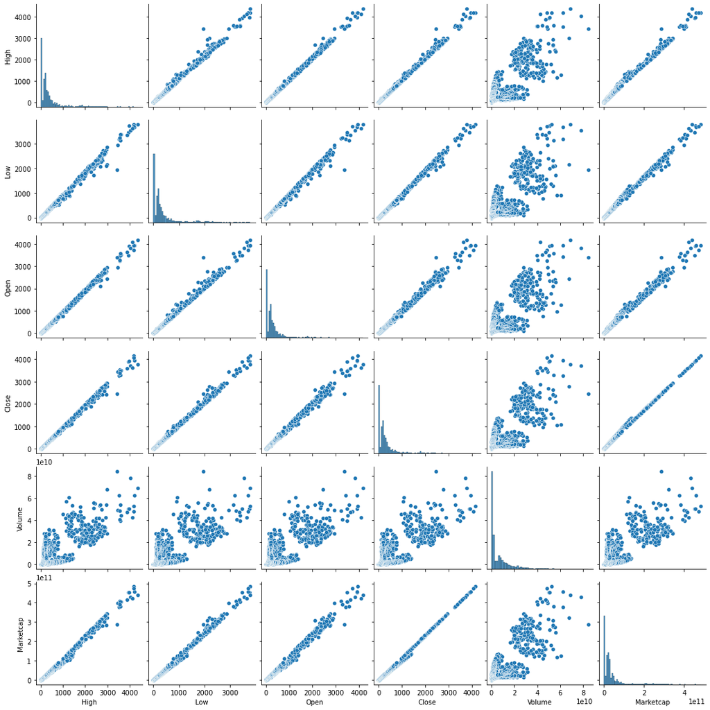

```python
sns.pairplot(df)
```

```python
average_price = df["Close"].mean()
```

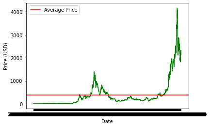

```python
#Plot the price of Ethereum over time
plt.plot(df["Date"], df["Close"], color="green")
plt.axhline(y=average_price, color="red", label="Average Price")
plt.xlabel("Date")
plt.ylabel("Price (USD)")
plt.legend()
plt.show()
```

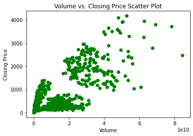

```python
# Create a scatter plot of volume vs. closing price
plt.scatter(df["Volume"], df["Close"], color="green")
plt.xlabel("Volume")
plt.ylabel("Closing Price")
plt.title("Volume vs. Closing Price Scatter Plot")
plt.show()
```

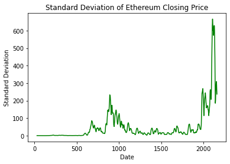

```python
#Calculate the standard deviation of the closing price
std = df["Close"].rolling(window=30).std()

# Create a line plot of the standard deviation
plt.plot(df.index, std, color="green")
plt.xlabel("Date")
plt.ylabel("Standard Deviation")
plt.title("Standard Deviation of Ethereum Closing Price")
plt.show()
```

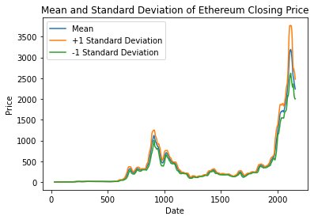

```python
# Calculate the mean and standard deviation of the closing price
mean = df["Close"].rolling(window=30).mean()
std = df["Close"].rolling(window=30).std()

# Create a line plot of the mean and standard deviation
plt.plot(df.index, mean, label="Mean")
plt.plot(df.index, mean + std, label="+1 Standard Deviation")
plt.plot(df.index, mean - std, label="-1 Standard Deviation")
plt.xlabel("Date")
plt.ylabel("Price")
plt.title("Mean and Standard Deviation of Ethereum Closing Price")
plt.legend()
plt.show()
```

```python
# Calculate the percentage growth of the closing price
start_price = 0.753325
end_price = 2324.679449
percent_growth = (end_price - start_price) / start_price * 100

print("Percentage growth of Ethereum price between 2015 and 2021: {:.2f}%".format(percent_growth))
```

```
Percentage growth of Ethereum price between 2015 and 2021: 308489.18%
```

Insights

- During the available time period we see ETH is a high growth asset that seems to display power law type returns
- Volume seems to have a positive effect on Closing price
- relatively stable standard deviation, but is susceptible to large price swings

Experiment setting

For the sake of this project we will use the median income of a full time employee in the United States as of 2022. The data source used for this analysis was an article from The balance citing data from the Bureau of Labor Statistics (BLS). Which states the median income to be at $54,132.

Based on this information the amount of wage per week is $1,041 and $4,511 per month not taking into account bills we will allocate 10% of income to the DCA stratgey.

Our budget will 451 USD per month, we will evaluate investment strategies using this budget based on different timeframes. The timeframes will conist of a single investment at the beginning of each month, week, and day.

Dispersed the investment schedule will be as follows Monthly = 12 investments of 451 usd per investment Weekly = 4 investments per month for a total of 52 of $112.5 per investment Daily = 28,30,or 31 investments of a total of 365 investments of 16.10, 15.03, 14.54 usd

```python
#Creating new columns representing the amount of ETH purchased using daily, weekly, and monthly budgets determined previously,
# using the closing price of ETH for that day
df['ETH_bought_daily'] = 15.22 / df['Close']
df['ETH_bought_weekly'] = 112.5 / df['Close']
df['ETH_bought_monthly'] = 451 / df['Close']
```

```python
#Lets check if the columns are succesfully created
df.head(10)
```

[output not shown]

```python
# Creation of the column "sum_eth_daily" to determine the cumulative sum of each ETH purchase.
df['ETH_sum_daily'] = df['ETH_bought_daily'] + df['ETH_bought_daily']
```

```python
#The new column is successful
df
```

[output not shown]

```python
df['ETH_sum_daily'].sum()
```

```
7347.734798547129
```

```python
# Define a custom function that takes two values and returns their product
def multiply_columns(col1, col2):
    return col1 * col2

#Use the apply method to apply the custom function to each row of the dataframe
df['daily_value'] = df.apply(lambda row: multiply_columns(row['Close'], row['ETH_sum_daily']), axis=1)
```

```python
df['daily_value'].sum()
```

```
65750.4
```

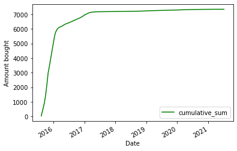

```python
# converting date column to datetime
df['Date'] = pd.to_datetime(df['Date'])

# setting date as index
df.set_index('Date', inplace=True)

# cumulative sum of purchases
df['cumulative_sum'] = df['ETH_sum_daily'].cumsum()

# plotting the cumulative sum
df['cumulative_sum'].plot(kind='line', color='green')
plt.xlabel("Date")
plt.ylabel("Amount bought")
plt.legend()
plt.show()
```

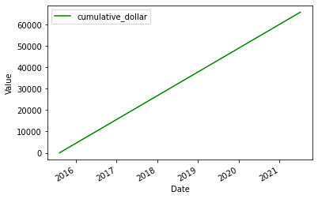

```python
# cumulative sum of purchases
df['cumulative_dollar'] = df['daily_value'].cumsum()

# plot the 'Value' column as a time series chart
# plotting the cumulative sum
df['cumulative_dollar'].plot(kind='line', color='green')
plt.xlabel("Date")
plt.ylabel("Value")
plt.legend()
plt.show()
```

Weekly

```python
# Creation of the column "sum_eth_daily" to determine the cumulative sum of each ETH purchase.
df['ETH_sum_weekly'] = df['ETH_bought_weekly'].iloc[1:] + df['ETH_bought_weekly']
```

```python
df['ETH_sum_weekly'].sum()
```

```
54012.76728009107
```

```python
# Define a custom function that takes two values and returns their product
def multiply_columns(col1, col2):
    return col1 * col2

#Use the apply method to apply the custom function to each row of the dataframe
df['weekly_value'] = df.apply(lambda row: multiply_columns(row['Close'], row['ETH_sum_weekly']), axis=1)
```

```python
df['weekly_value'].sum()
```

```
485775.0
```

With the columns created, an investment analysis is performed where 2160 (5.9 years) purchases are executed, as 1825 days are equivalent to 5 years with daily purchases, resulting in an accumulation of 54012.77 ETH. Resulting in a dollar value of $485,775.0

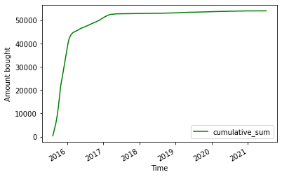

```python
# cumulative sum of purchases
df['cumulative_sum'] = df['ETH_sum_weekly'].cumsum()

# plot the 'Value' column as a time series chart
# plotting the cumulative sum
df['cumulative_sum'].plot(kind='line', color='green')
plt.xlabel("Time")
plt.ylabel("Amount bought")
plt.legend()
plt.show()
```

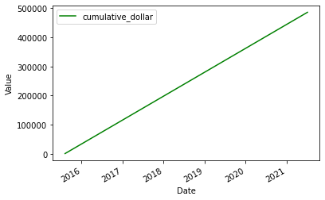

```python
# cumulative sum of purchases
df['cumulative_dollar'] = df['weekly_value'].cumsum()

# plot the 'Value' column as a time series chart
# plotting the cumulative sum
df['cumulative_dollar'].plot(kind='line', color='green')
plt.xlabel("Date")
plt.ylabel("Value")
plt.legend()
plt.show()
```

Monthly

```python
# Creation of the column "sum_eth_daily" to determine the cumulative sum of each ETH purchase.
df['ETH_sum_monthly'] = df['ETH_bought_monthly'].iloc[1:] + df['ETH_bought_monthly']
```

```python
df['ETH_sum_monthly'].sum()
```

```
216531.18260729845
```

```python
# Define a custom function that takes two values and returns their product
def multiply_columns(col1, col2):
    return col1 * col2

#Use the apply method to apply the custom function to each row of the dataframe
df['monthly_value'] = df.apply(lambda row: multiply_columns(row['Close'], row['ETH_sum_monthly']), axis=1)
```

```python
df['monthly_value'].sum()
```

```
1947418.0
```

With the columns created, an investment analysis is performed where 2160 (5.9 years) purchases are executed, as 1825 days are equivalent to 5 years with daily purchases, resulting in an accumulation of 216531.18 ETH. Resulting in a dollar value of $1,947,418.0

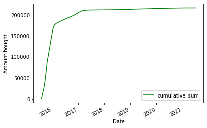

```python
# cumulative sum of purchases
df['cumulative_sum'] = df['ETH_sum_monthly'].cumsum()

# plotting the cumulative sum
df['cumulative_sum'].plot(kind='line', color='green', )
plt.xlabel("Date")
plt.ylabel("Amount bought")
plt.legend()
plt.show()
```

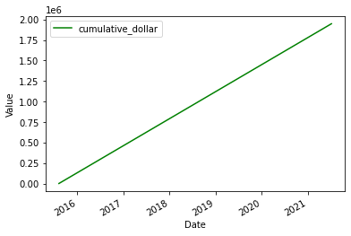

```python
# cumulative sum of purchases
df['cumulative_dollar'] = df['monthly_value'].cumsum()

# plot the 'Value' column as a time series chart
# plotting the cumulative sum
df['cumulative_dollar'].plot(kind='line', color='green')
plt.xlabel("Date")
plt.ylabel("Value")
plt.legend()
plt.show()
```

Addressing Vol

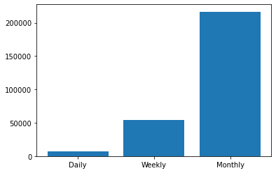

```python
# The three values
values = [7307.327271137655, 54012.76728009107, 216531.18260729845]


# Create a bar chart
plt.bar(x=['Daily', 'Weekly', 'Monthly'], height=values)
plt.show()
```

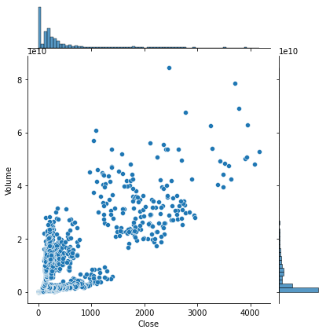

```python
sns.jointplot(data=df, x='Close', y="Volume", markers=['o']);
```

[figure not shown]

```
interactive(children=(IntSlider(value=7, description='i', max=14), Output()), _dom_classes=('widget-interact',…
```

```python
# Create a pairplot
g = sns.pairplot(df)

# Define a function to display the plot with a scrolling area
@interact
def show_pairplot(i=(0, len(df.columns) - 1)):
    pair = np.array(np.meshgrid(df.columns, df.columns)).T.reshape(-1, 2)
    selected = pair[i*4:(i+1)*4]
    plt.clf()
    for x, y in selected:
        sns.scatterplot(x=x, y=y, data=df)
    plt.show()
```

Using Log to check the effects of volume on accumulation

We see that regardless of vol we get a power law L shaped graph, when means that this strategy generally does well with accumulation. But when we look at the amount of accumulation per interval we can see that volume does have a significant effect on accumulation. From the data, we can conclude that in a volatile asset it is better to distribute capital in chunks consistently, in order to mitigate volume associate risk the most.

```python
ethx = df['ETH_bought_daily']
ethxx = df['ETH_bought_weekly']
ethxxx = df['ETH_bought_monthly']
ethd_log = np.log(ethx)
ethw_log = np.log(ethxx)
ethm_log = np.log(ethxxx)
```

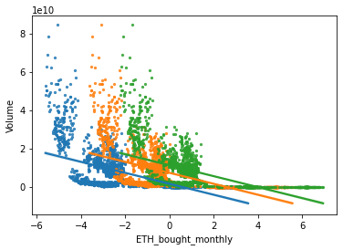

```python
# Plot the logarithmic regression
sns.regplot(x=ethd_log, y=df['Volume'], scatter_kws={'s': 5})
sns.regplot(x=ethw_log, y=df['Volume'], scatter_kws={'s': 5})
sns.regplot(x=ethm_log, y=df['Volume'], scatter_kws={'s': 5})
```

Below we further see a power law L shaped chart. But judging by the Spearman correlation as the amount of volume increases the amount bought decreases. The p-value of 0.0 shows that we can accept this hypothesis.

```
The Spearman correlation coefficient is: -0.7326540426431455
The p-value is: 0.0
```

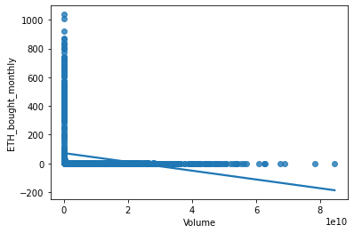

```python
from scipy.stats import spearmanr

# Load your data into the DataFrame named 'df'

# Extract the columns that you want to calculate the Spearman correlation coefficient for
x = df['Volume']
y = df['ETH_bought_monthly']

# Calculate the Spearman correlation coefficient
coefficient, p_value = spearmanr(x, y)

print("The Spearman correlation coefficient is:", coefficient)
print("The p-value is:", p_value)

# Create a scatter plot with a regression line
sns.regplot(x=x, y=y, ci=None)

# Show the plot
plt.show()
```

- Volume is needed to drive price action but it negatively affects accumulation
- From initial analyses its better to maximize the amount invested in order to maximize accumulation and mitigate the risk of volume.

Calculate ROI

```python
# Function to calculate ROI
def calculate_roi(row):
    return (row['monthly_value'] - row['ETH_sum_monthly']) / row['ETH_sum_monthly'] * 100

# Apply the function to the DataFrame
df['monthly_ROI'] = df.apply(calculate_roi, axis=1)
```

```python
df['monthly_ROI'].sum()
```

```
82708733.99248391
```

```python
df['monthly_ROI']
```

```
Date
2015-08-08 23:59:59              NaN
2015-08-09 23:59:59       -29.810297
2015-08-10 23:59:59       -29.155201
2015-08-11 23:59:59         6.786001
2015-08-12 23:59:59        21.744001
                           ...
2021-07-02 23:59:59    214904.036404
2021-07-03 23:59:59    222511.428196
2021-07-04 23:59:59    232072.411157
2021-07-05 23:59:59    219758.246387
2021-07-06 23:59:59    232367.944917
Name: monthly_ROI, Length: 2160, dtype: float64
```

Conclusions

- Investing 10% of the average full-time employee salary in the US in the ETH through the DCA strategy can change one's life completely.
- While any timeframe generally works, there is a significant difference in how much accumulation occurs and how exposed you are to volatility. This may be asset related but the longer the timeframe of disbursement the more effective the strategy
- It was determined that the Return of investment (ROI) after 5 years of investment exceeds 2000% based on the unrealized returns on the last day of purchases in each time frame (daily, weekly, monthly).